# Continous Probability Distributions

- Show All Code
- Hide All Code

So far, we’ve been talking about discrete probability distributions where the outcomes of experiments are represented by countable whole numbers. For example, rolling a die can result in a two or three, but not a decimal values such as 2.178 or 3.394. Now, we’ll move from discrete to continuous probability distributions. Recall that continuous probability deals with outcomes that can take on all the values in a range of numbers. Typically, these are decimal values that can be measured such as: height, weight, time, or temperature. For example, you can keep on measuring time with more accuracy: 1.1 seconds, 1.12 seconds, 1.1257 seconds, and so on. In this video, we’ll explore the most widely used probability distribution in statistics, the normal distribution.

**The normal distribution is a continuous probability distribution that is symmetrical on both sides of the mean and bell-shaped**. The normal distribution is often called the bell curve because its graph has the shape of a bell with a peak at the center and two downward-sloping sides. It is also known as the Gaussian distribution after the German mathematician Carl Gauss who first described the formula for the distribution.

While we’re on the subject of formulas, if you want to learn more about this formula, please check out the relevant reading where it’s discussed in more detail. The normal distribution is the most common probability distribution in statistics because so many different kinds of data sets display a bell-shaped curve. For example, if you randomly sample 100 people you’ll discover a normal distribution curve for continuous variables, such as: height, weight, blood pressure, IQ scores, salaries, and more. For example, think of the typical results of standardized tests. The majority of people will score close to the average score or mean. Fewer numbers of people will score below or above average farther out from the mean. A very small percentage of people will score extremely high or extremely low. Very far away from the mean. This distribution of scores generates a bell curve. Most of the data values are relatively close to the mean. The farther a value is away from the mean, the less likely it is to occur.

On a normal curve the x-axis refers to the value of the variable you’re measuring and the y-axis refers to how likely you are to observe the value. In the case of test scores, the x-axis is the raw score and the y-axis is the percentage of the population that gets that score.

Data professionals use the normal distribution to model all kinds of different data sets in the fields of business, science, government, machine learning, and others. Understanding the normal distribution is also important for more advanced statistical methods such as hypothesis testing and regression analysis which you’ll learn more about later. Plus many machine learning algorithms assume that data is normally distributed.

All normal distributions have the following features:

- the shape is a bell curve,
- the mean is located at the center of the curve,
- the curve is symmetrical on both sides of the center,
- and the total area under the curve equals 1.

To clarify the features of the normal distribution, let’s graph the weights of honeycrisp apples. Assume that the weights of honeycrisp apples are approximately normally distributed with a mean of 100 grams and a standard deviation of 15 grams. First, find the mean at the center of the curve. This is also the highest point or peak of the curve. This data point represents the most probable outcome in the data set, mean weight of 100 grams. Second, notice that the curve is symmetrical on each side of the mean. Fifty percent of the data is above the mean, and 50 percent is below the mean. Third, the farther a point is away from the mean, the lower the probability of those outcomes. The points farthest from the mean represent the least probable outcomes in the data set. These are apples that have more extreme weights, either low or high. Finally, the area under the curve is equal to 1. This means that the area under the curve accounts for 100 percent of the possible outcomes in the distribution.

```python
import matplotlib.pyplot as plt
import numpy as np
from scipy.stats import norm

# 1. Define distribution parameters: mean = 100g, std dev = 15g
mean = 100
std_dev = 15

# Generate x range spanning -3.5 to +3.5 standard deviations
x = np.linspace(mean - 3.5 * std_dev, mean + 3.5 * std_dev, 1000)
y = norm.pdf(x, mean, std_dev)

# Setup figure and axes
fig, ax = plt.subplots(figsize=(11, 6))

# 2. Define standard deviation boundary points
x_55, x_70, x_85, x_100, x_115, x_130, x_145 = [
    mean + i * std_dev for i in range(-3, 4)
]

# Color fills matching the image regions
# Central area (±1 std dev: 85g to 115g) - Blue
ax.fill_between(
    x, y, where=(x >= x_85) & (x <= x_115), color="#4C70F5", alpha=0.9
)

# Middle wings (±2 std dev: 70g-85g & 115g-130g) - Yellow/Amber
ax.fill_between(
    x, y, where=(x >= x_70) & (x <= x_85), color="#FFC000", alpha=0.9
)
ax.fill_between(
    x, y, where=(x >= x_115) & (x <= x_130), color="#FFC000", alpha=0.9
)

# Outer wings (±3 std dev: 55g-70g & 130g-145g) - Red
ax.fill_between(
    x, y, where=(x >= x_55) & (x <= x_70), color="#E51C23", alpha=0.9
)
ax.fill_between(
    x, y, where=(x >= x_130) & (x <= x_145), color="#E51C23", alpha=0.9
)

# Draw vertical segment boundary lines
boundaries = [x_55, x_70, x_85, x_115, x_130, x_145]
for b in boundaries:
    ax.vlines(
        x=b, ymin=0, ymax=norm.pdf(b, mean, std_dev), color="white", lw=1.5
    )

# Center line at mean (100g)
ax.vlines(
    x=x_100,
    ymin=0,
    ymax=norm.pdf(x_100, mean, std_dev),
    color="white",
    lw=2,
)

# 3. Add percentage labels above each segment
ax.text(92.5, 0.023, "34%", fontsize=11, ha="center")
ax.text(107.5, 0.023, "34%", fontsize=11, ha="center")
ax.text(77.5, 0.011, "14%", fontsize=11, ha="center")
ax.text(122.5, 0.011, "14%", fontsize=11, ha="center")
ax.text(62.5, 0.0035, "2%", fontsize=11, ha="center")
ax.text(137.5, 0.0035, "2%", fontsize=11, ha="center")

# Boxed labels for 0.1% extreme tails

ax.text(48, 0.0035, "0.1%", fontsize=10, ha="center")
ax.text(152, 0.0035, "0.1%", fontsize=10, ha="center")

# 4. Add horizontal double-headed arrows for cumulative range percentages (68%, 95%, 99.7%)
# 68% range arrow
ax.annotate(
    "",
    xy=(x_85, 0.016),
    xytext=(x_115, 0.016),
    arrowprops=dict(arrowstyle="<->", color="white", lw=1.5),
)
ax.text(
    x_100,
    0.016,
    " 68% ",
    color="white",
    fontsize=11,
    fontweight="bold",
    ha="center",
    va="center",
    bbox=dict(fc="#4C70F5", ec="none", pad=1),
)

# 95% range arrow
ax.annotate(
    "",
    xy=(x_70, 0.0025),
    xytext=(x_130, 0.0025),
    arrowprops=dict(arrowstyle="<->", color="white", lw=1.5),
)
ax.text(
    x_100,
    0.0025,
    " 95% ",
    color="white",
    fontsize=11,
    fontweight="bold",
    ha="center",
    va="center",
    bbox=dict(fc="#4C70F5", ec="none", pad=1),
)

# 99.7% range arrow
ax.annotate(
    "",
    xy=(x_55, 0.0008),
    xytext=(x_145, 0.0008),
    arrowprops=dict(arrowstyle="<->", color="white", lw=1.5),
)
ax.text(
    x_100,
    0.0008,
    " 99.7% ",
    color="white",
    fontsize=10,
    fontweight="bold",
    ha="center",
    va="center",
    bbox=dict(fc="#4C70F5", ec="none", pad=1),
)

# 5. Axis formatting to match the clean reference style with arrow axes
ax.spines["top"].set_visible(False)
ax.spines["right"].set_visible(False)
ax.spines["left"].set_position(("data", 40))
ax.spines["bottom"].set_position(("data", 0))

# Add arrows to x and y axis ends
ax.plot(40, max(y) * 1.05, "^k", transform=ax.transData, clip_on=False)
ax.plot(160, 0, ">k", transform=ax.transData, clip_on=False)

# Custom tick marks and labels
ax.set_xticks([x_55, x_70, x_85, x_100, x_115, x_130, x_145])
ax.set_xticklabels(
    ["55g", "70g", "85g", "100g", "115g", "130g", "145g"], fontsize=10
)
ax.set_yticks([])  # Remove y-axis numbers

# Title and axis labels
ax.set_title("Apple Weight Distribution", fontsize=16, pad=20)
ax.set_xlabel("Apple Weight", fontsize=11, labelpad=10)
ax.set_ylabel("Percentage of apple", fontsize=11, labelpad=15)

# Limits
ax.set_xlim(38, 162)
ax.set_ylim(0, max(y) * 1.05)

plt.tight_layout()
plt.show()
```

[output not shown]

On a normal distribution, the distance of a data point from the mean is often measured in standard deviations. As a refresher, the standard deviation calculates the typical distance of a data point from the mean of your data set. While the mean refers to the center of your data, the standard deviation measures spread. As standard deviations become larger, data values become more spread out from the mean. In our apple example, the mean weight is 100 grams and the standard deviation is 15 grams, so an apple that is one standard deviation above the mean will weigh 115 grams with the mean weight of 100 grams plus the standard deviation of 15 grams. An apple that is one standard deviation below the mean will weigh 85 grams or 100 grams minus 15 grams. An apple that’s two standard deviations above the mean will weigh 130 grams, and an apple that’s two standard deviations below the mean will weigh 70 grams.

The values on a normal curve are distributed in a regular pattern based on their distance from the mean. This is known as **the empirical rule. It states that for a given data set with a normal distribution, 68 percent of values fall within one standard deviation of the mean, 95 percent of values fall within two standard deviations of the mean, and the 99.7 percent of values fall within three standard deviations of the mean.**

The empirical rule can give you a clear idea of how the values in your data set are distributed which helps you save time and better understand your data. Let’s continue with our apple example. The empirical rule tells you that most apples were 68 percent will fall within one standard deviation of the mean weight of 100 grams. This means that 68 percent of apples will weigh between 85 grams which is one standard deviation below the mean, and 115 grams, one standard deviation above the mean. Ninety-five percent of apples will weigh between 70 grams and 130 grams or within two standard deviations from the mean. Almost all apples or 99.7 percent will weigh between 55 grams and then 145 grams, or within three standard deviations of the mean.

The empirical rule is useful for estimating data, especially for large data sets like height and weight data for an entire population. You can use the empirical rule to get an initial estimate of the distribution of values in your data set such as what percentage of values will fall within one, two, or three standard deviations of the mean. This saves time and helps you better understand your data. Plus, knowing the location of your values on a normal distribution is useful for detecting outliers. Recall that an outlier is a value that differs significantly from the rest of the data.

**Typically, data professionals consider values that lie more than three standard deviations below or above the mean to be outliers.** It’s important to identify outliers because some extreme values may be due to errors in data collection or data processing. These false values may skew the results of your analysis.

Let’s explore another example of how the empirical rule can help you better understand your data. Imagine you have a garden, the height of your plants is normally distributed with a mean of 32.1 inches and a standard deviation of 2.2 inches. Let’s say you want to find out what percentage of plants are greater than 29.9 inches tall. You want your plants to be at least this tall as part of your landscape design plan for your backyard. First, find out where the value 29.9 is located on the distribution. Twenty-nine point nine is located one standard deviation below the mean. The empirical rule tells you that 68 percent of values fall within one standard deviation of the mean. Half of these values or 34 percent fall below the mean. Now you know that 34 percent of values are between 29.9 and the mean because 29.9 is one standard deviation below the mean plus 50 percent of all values in a normal distribution fall above the mean or center of the curve. The sum of these two percentages will tell you the overall percentage of values greater than 29.9. 34 percent plus 50 percent equals 84 percent, so 84 percent of your plants are greater than 29.9 inches tall. The empirical rule helps you quickly understand the overall distribution of your data values. Now you know that most of your plants are tall enough for your landscape design plan. As a future data professional, you use the normal distribution to identify significant patterns in a wide variety of data sets.

# 1 Model data with the normal distribution

Recently, you’ve been learning about continuous probability distributions, and how they help data professionals model their data. Recall that continuous probability distributions represent continuous random variables, which can take on all the possible values in a range of numbers. Typically, these are decimal values that can be measured, such as height, weight, time, or temperature. For example, you can keep on measuring time with more accuracy: 1.1 seconds, 1.12 seconds, 1.1257 seconds, and so on.

In this course, we focus on a single continuous probability distribution: the normal distribution. In this reading, you’ll learn more about the main characteristics of the normal distribution, and how the distribution can help you model your data.

Before we get to the specific attributes of the normal distribution, let’s discuss some general features of all continuous probability distributions.

## 1.1 **Probability Density and Probability**

**A probability function is a mathematical function that provides probabilities for the possible outcomes of a random variable.**

There are two types of probability functions:

- **Probability Mass Functions (PMFs) represent discrete random variables**
- **Probability Density Functions (PDFs) represent continuous random variables**

A probability function can be represented as an equation or a graph. The math involved in probability functions is beyond the scope of this course. For now, it’s important to know that the graph of a PDF appears as a curve. You’ve learned about the bell curve, which refers to the graph for a normal distribution.

As an example, imagine you have data on a random sample of cherry trees. Assume that the heights of the cherry trees are approximately normally distributed with a mean of 15 feet and a standard deviation of 2 feet.

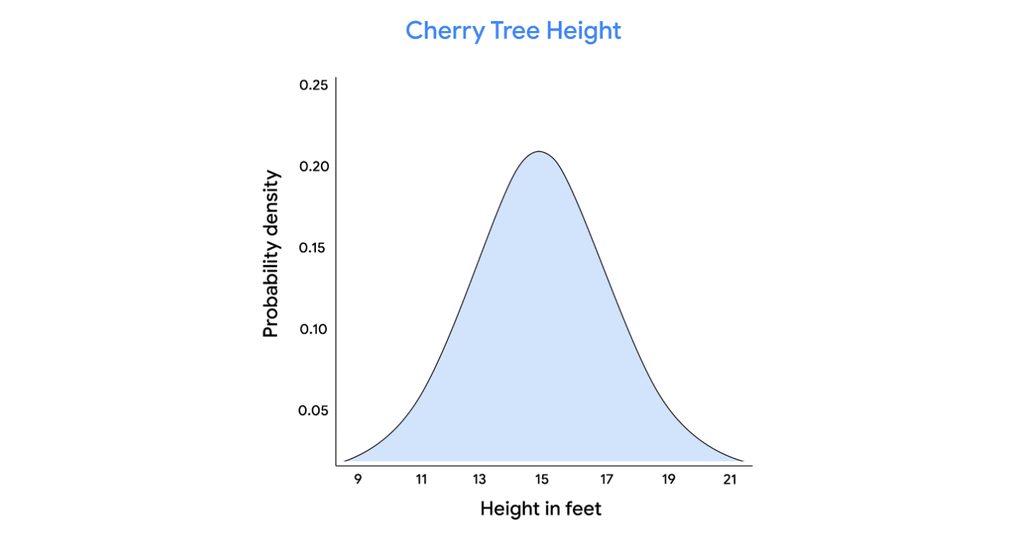

On a continuous distribution, the x-axis refers to the value of the variable you’re measuring - in this case, cherry tree height. The y-axis refers to probability density. **Note that probability density is not the same thing as probability.**

**The probability distribution for a continuous random variable can only tell you the probability that the variable takes on a range or interval of values. This is because a continuous random variable may have an infinite number of possible values.** For instance, the height of a randomly chosen cherry tree could measure 15 feet, or 15.1 feet, or 15.175 feet, or 15.175245 feet, and so on.

Let’s say you want to know the probability that the height of a randomly chosen cherry tree is exactly 15.1 feet. Because the height of the tree could be any decimal value in a given interval, the probability that the tree is exactly any single value is essentially zero.

So, for continuous distributions, it only makes sense to talk about the probability of intervals, such as the interval between 14.5 feet and 15.5 feet.

To find the probability of an interval, **you calculate the area under the curve that corresponds to the interval.** For example, the probability of a cherry tree having a height between 14.5 feet and 15.5 feet is equal to the area under the curve between the values 14.5 and 15.5 on the x-axis. This area appears as the shaded rectangle in the center of the graph.

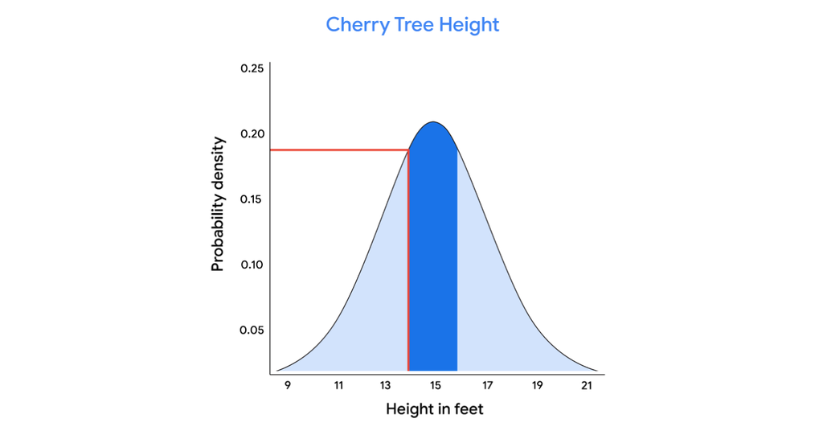

In this case, the area of the rectangle is around 0.20. So, there is a 20% chance that the height of a randomly chosen cherry tree is between 14.5 feet and 15. 5 feet.

**Note:** data professionals typically use statistical software to calculate probabilities on a continuous distribution.

## 1.2 **The normal distribution**

The normal distribution is a continuous probability distribution that is symmetric about the mean and bell-shaped. It is also known as the Gaussian distribution, after the German mathematician Carl Gauss, who first described its formula. The normal distribution is often called the bell curve because its graph has the shape of a bell, with a peak at the center and two downward sloping sides.

The normal distribution is the most common probability distribution in statistics because so many different kinds of datasets display a bell-shaped curve. For example, if you randomly sample 100 people, you will discover a normal distribution curve for continuous variables such as height, weight, blood pressure, shoe size, test scores, and more.

All normal distributions have the following features:

- The shape is a bell curve
- The mean is located at the center of the curve
- The curve is symmetrical on both sides of the mean
- The total area under the curve equals 1

Let’s use our cherry tree example to clarify the features of the normal distribution. Recall that the mean height is 15 feet with a standard deviation of 2 feet.

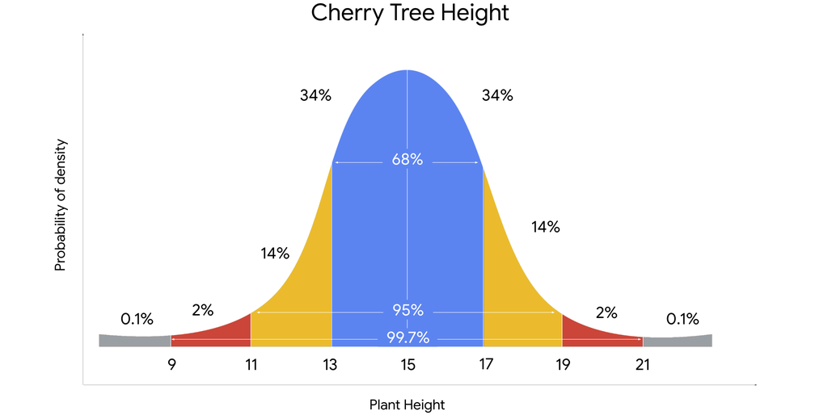

You may notice the following features of the normal curve:

- The mean is located at the center of the curve, and is also the peak of the curve. The mean height of 15 feet represents the most probable outcome in the dataset
- The curve is symmetrical about the mean. 50% of the data is above the mean, and 50% of the data is below the mean
- The farther a point is from the mean, the lower the probability of those outcomes. The points farthest from the mean represent the least probable outcomes in the dataset. These are trees that have more extreme heights, either short or tall
- The area under the curve is equal to 1. This means that the area under the curve accounts for 100% of the possible outcomes in the distribution

## 1.3 **The empirical rule**

You may also notice that the values on a normal curve are distributed in a regular pattern, based on their distance from the mean. This is known as **the empirical rule.** The rule states that for a given dataset with a normal distribution:

- 68% of values fall within 1 standard deviation of the mean
- 95% of values fall within 2 standard deviations of the mean
- 99.7% of values fall within 3 standard deviations of the mean

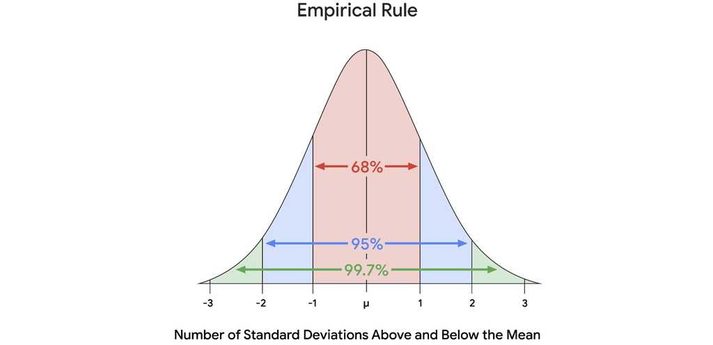

If you apply the empirical rule to our cherry tree example, you learn the following:

- Most trees, or 68%, will fall within 1 standard deviation of the mean height of 15 feet. This means that 68% of trees will measure between 13 feet and 17 feet, or 2 feet below the mean and 2 feet above the mean
- 95% of trees will measure between 11 feet and 19 feet, or within 2 standard deviations from the mean
- Almost all trees, or 99.7%, will measure between 9 feet and 21 feet, or within 3 standard deviations of the mean

The empirical rule can give you a quick estimate of how the values in a large dataset are distributed. This saves time and helps you better understand your data.

Knowing the location of your values on a normal distribution is also useful for detecting outliers. Recall that an outlier is a value that differs significantly from the rest of the data. Typically, data professionals consider values that lie more than 3 standard deviations below or above the mean to be outliers. It’s important to identify outliers because some extreme values may be due to errors in data collection or data processing, and these false values may skew your results.

## 1.4 Key takeaways

As a data professional, you’ll likely use the normal distribution to identify significant patterns in a wide variety of datasets. Understanding the normal distribution is also important for more advanced statistical methods, such as hypothesis testing and regression analysis, which you’ll learn about later on.

## 1.5 Resources for more information

To learn more about continuous probability distributions and the normal distribution, check out the following resources:

- This [article from Duke University provides a useful summary of the main characteristics of the normal distribution](https://sites.nicholas.duke.edu/statsreview/continuous-probability-distributions/)

# 2 Standardize data using z-scores

Recently, you learned about the normal distribution and how it applies to many different kinds of data sets. In this video, you’ll learn about $z$-scores and how they can help you compare values from different types of normally distributed data sets.

**A $z$-score is a measure of how many standard deviations below or above the population mean a data point is. A $z$-score gives you an idea of how far from the mean a data point is.** For example, the $z$-score is 0, if the value is equal to the mean. The $z$-score is positive if the value is greater than the mean. The $z$-score is negative if the value is less than the mean.

$z$-scores help you standardize your data. In statistics, **standardization is the process of putting different variables on the same scale.** There is a formula for this which will check out a little later.

$z$-scores are also called standard scores because they’re based on what’s called the standard normal distribution. **A standard normal distribution is just a normal distribution with a mean of 0 and a standard deviation of 1.**

$z$-scores typically range from -3 to +3. Standardization is useful because it lets you compare scores from different data sets that may have different units, mean values and standard deviations.

Data professionals use $z$-scores to better understand the relationship between data values within a single dataset and between different data sets. For example, **data professionals often use $z$-scores for anomaly detection**, which finds outliers in datasets. Applications of anomaly detection include finding fraud in financial transactions, flaws in manufacturing products, intrusions in computer networks and more.

For example, different customer satisfaction surveys may have different rating scales. One survey could rate a product or service from 1 to 20, another from 500 to 1,500, and a third from 130 to 180. Let’s say the same product got a score of 9 on the first survey, 850 on the second and 142 on the third. These numbers don’t mean much by themselves, but if you know, they all have a $z$-score of 1, or one standard deviation above the mean, you can meaningfully compare ratings across surveys.

A $z$-score for an individual value can be interpreted as follows. A $z$-score of 1 is one standard deviation above the mean. A $z$-score of 1.5 is 1.5 standard deviations above the mean. A $z$-score of -2.3 is 2.3 standard deviations below the mean.

Every $Z$-score is built on the exact same ratio: ($Z = \frac{\text{Signal}}{\text{Noise}}$)

$$Z = \frac{\text{Observed} - \text{Expected} }{\text{Standard Deviation}}$$

You can use the following formula to calculate a $z$-score,
$$Z = \frac{X-\mu}{\sigma}$$

- In this formula, x refers to a single data value or raw score.
- The Greek letter mu $\mu$ refers to population mean.
- The Greek letter sigma $\sigma$ refers to the population standard deviation.

So we can also say that Z equals the raw score or data value minus the mean divided by the standard deviation.

For example, let’s say you take a standardized test, you have a test score of 133. The test has a mean score of 100 and a standard deviation of 15. Assuming a normal distribution, you can use the formula to calculate your $z$-score.

$$Z = \frac{133-100}{15} =2.2$$

Your $z$-score is your raw score, 133 minus the mean score, 100 divided by the standard deviation 15. This is 133 minus 100 divided by 15 equals 33 divided by 15 equals 2.2.

Your $z$-score of 2.2 tells you that your test score is 2.2 standard deviations above the mean or average score. That’s a really good score. Recall that the empirical rule tells you that 95% of values fall within two standard deviations of the mean. Your score of 2.2 is more than two standard deviations above the mean. $z$-scores are useful because they give us an idea of how an individual value compares to the rest of the distribution.

Let’s take a different exam with a different grading scale. Say you score in 85, you want to find out if that’s a good score relative to the rest of the class.

Whether or not it’s a good score depends on the mean and standard deviation of all exam scores. Suppose the exam scores are normally distributed with a mean score of 90 and a standard deviation of 4, you can use the formula to calculate the $z$-score of a raw score of 85.

$$Z = \frac{85-90}{4} =-1.25$$

Your $z$-score is yours raw score, 85 minus the mean score 90, divided by the standard deviation 4. This is 85 minus 90 divided by 4 equals -5, divided by 4 equals -1.25. Your $z$-score of -1.25 tells you that your exam score of 85 is 1.25 standard deviations below the mean or average exam score.

$z$-scores give you an idea of how individual values compared to the mean. As a data professional, you’ll use $z$-scores to help you better understand the relationship between specific values in your data set.

You’ll most likely use a programming language like Python to calculate $z$-scores on your computer as you’’ll learn in an upcoming video.

When I deal with a new dataset, I first go through the process of EDA and compute descriptive stats to get a basic understanding of my data. After that, I try to determine if my data fits a certain type of probability distribution, like the binomial, Poisson, and normal distributions you recently learned about.

Knowing the distribution of my data helps me decide what statistical test or machine learning model will work best for my analysis.

Python has a great selection of function libraries for data analysis. Using Python to work with distributions saves time and improves the overall efficiency of my analysis.

In this video, you’ll use Python to model your data with the normal distribution. Then you’ll compute $z$-scores to find any outliers in your data.

We’ll continue with our previous scenario in which you’re a data professional working for the Department of Education of a large nation. Recall that you’re analyzing data on the literacy rate for each district, and you’ve already computed descriptive statistics to summarize your data. You’ll continue to use the dataset you worked with before. If you need to access the data, do so now. Along with pandas, NumPy, and matplotlib.pyplot, you’ll use two Python packages that may be new to you: SciPy stats and statsmodels. SciPy is an open source software you can use for solving mathematical, scientific, engineering, and technical problems. It allows you to manipulate and visualize data with a wide range of Python commands. SciPy stats is a module designed specifically for statistics. Statsmodels is a Python package that lets you explore data, work with statistical models, and perform statistical tests. It includes an extensive list of stats functions for different types of data.

Now that you know more about the packages you’ll be working with, let’s open up a Jupyter Notebook and load them up. To start, import the Python packages you will use: NumPy, pandas, and statsmodels.api and the library you will use matplotlib.pyplot. To save time, rename each package and library within abbreviation: NP, PD, PLT, and SM. To load the SciPy stats module right, from SciPy import stats.

```python
import numpy as np
import pandas as pd
import matplotlib.pyplot as plt
from scipy import stats
import statsmodels.api as sm
```

```python
education_districtwise = pd.read_csv(r'Datasets\education_districtwise.csv')
education_districtwise = education_districtwise.dropna()
```

For the next part of your analysis, you want to find out if the data on literacy rate fits a specific type of probability distribution.

The first step in trying to model your data with a probability distribution is to plot a histogram. This will help you visualize the shape of your data and determine if it resembles the shape of a specific distribution. Use matplotlib’s histogram function to plot a histogram of the district literacy rate data. Recall that the overall_li column contains this data.

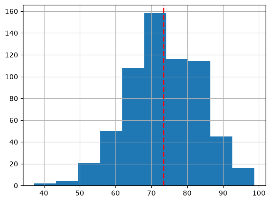

```python
mean_val = education_districtwise["OVERALL_LI"].mean()
education_districtwise.OVERALL_LI.hist()
plt.axvline(
    mean_val,
    color="red",
    linestyle="dashed",
    linewidth=2,
    label=f"Mean: {mean_val:.2f}",
)
```

```python
import plotly.express as px

fig = px.histogram(education_districtwise, 'OVERALL_LI')
fig.add_vline(
    x=mean_val,
    line_dash="dash",
    line_color="red",
    annotation_text=f"Mean: {mean_val:.2f}",
    annotation_position="top right",
)
fig.show()
```

[output not shown]

The x-axis of your plot refers to the literacy rate of each district, and the y-axis refers to count or to the number of districts. The histogram shows that the distribution of your literacy rate data is bell-shaped and symmetric about the mean. Recall that the normal distribution is a continuous probability distribution that is bell-shaped and symmetrical on both sides of the mean. The mean literacy rate, which is around 73 percent, is located in the center of the plot. The shape of your histogram suggests that the normal distribution might be a good modeling option for your data. To verify that your data is normally distributed, you can use Python to find out if your data follows the empirical rule. Recall that the empirical rule says that for every normal distribution, about 68 percent of values fall within one standard deviation of the mean, 95 percent fall within two standard deviations of the mean, and 99.7 percent fall within three standard deviations of the mean.

Since the normal distribution seems like a good fit for the district literacy rate data, you can expect the empirical rule to apply relatively well. In other words, you can expect that about 68 percent of literacy rates will fall within one standard deviation of the mean, 95 percent will fall within two standard deviations, and 99.7 percent will fall within three standard deviations.

First, name two new variables to store the values for the mean and standard deviation of the district literacy rate. Name your first variable mean_overall_li and compute the mean. Display the value of your variable. The mean district literacy rate is about 73.4 percent.

```python
mean_overall_li = education_districtwise['OVERALL_LI'].mean()
mean_overall_li
```

```
np.float64(73.39518927444796)
```

Name your second variable std_overall_li and compute the standard deviation and display the value of your variable.  The standard deviation is about 10 percent. If your data follows the empirical rule, you can expect roughly 68 percent of your values to fall within one standard deviation of the mean district literacy rate of 73 percent.

```python
std_overall_li = education_districtwise['OVERALL_LI'].std()
std_overall_li
```

```
np.float64(10.098460413782467)
```

One standard deviation below the mean is 63 percent, or 73 minus 1 times 10. One standard deviation above the mean is 83 percent, or 73 plus 1 times 10. So you can expect roughly 68 percent of your values to fall within this range of 63-83 percent. Now compute the actual percentage of district literacy rates that fall within one standard deviation of the mean. To do this, first name two new variables, lower_limit and upper_limit. The lower limit will be one standard deviation below the mean, or the mean minus 1 times the standard deviation. The upper limit will be one standard deviation above the mean, or the mean plus 1 times the standard deviation.

To write the code for the calculations, use your two previous variables mean_overall_li and std_overall_li for the mean and standard deviation.

Next, add a line of code that tells the computer to decide if each value in the overall literacy column is between the lower limit and upper limit. In other words, to decide if each value is greater than or equal to one standard deviation below the mean and less than or equal to one standard deviation above the mean. For this we create a boolean mask using & to check if each district’s literacy rate is both greater than or equal to lower_limit and less than or equal to upper_limit. This results in a Series of True and False values.

Because Pandas treats True as 1 and False as 0, calling .mean() sums all the 1s (the districts within standard deviation limits) and divides by the total number of rows (1s and 0s combined). This directly returns the proportion of districts falling within one standard deviation of the mean.

```python
lower_limit = mean_overall_li - 1 * std_overall_li
upper_limit = mean_overall_li + 1 * std_overall_li
((education_districtwise['OVERALL_LI'] >= lower_limit) & (education_districtwise['OVERALL_LI'] <= upper_limit)).mean()
```

```
np.float64(0.6640378548895899)
```

```python
lower_limit = mean_overall_li - 2 * std_overall_li
upper_limit = mean_overall_li + 2 * std_overall_li
((education_districtwise['OVERALL_LI'] >= lower_limit) & (education_districtwise['OVERALL_LI'] <= upper_limit)).mean()
```

```
np.float64(0.9542586750788643)
```

```python
lower_limit = mean_overall_li - 3 * std_overall_li
upper_limit = mean_overall_li + 3 * std_overall_li
((education_districtwise['OVERALL_LI'] >= lower_limit) & (education_districtwise['OVERALL_LI'] <= upper_limit)).mean()
```

```
np.float64(0.9968454258675079)
```

About 0.954 or 95.4 percent of your values fall within two standard deviations of the mean, and about 0.996 or 99.6 percent of your values fall within three standard deviations of the mean.

Here, values of 66.4, 95.4, and 99.6 percent are very close to what the empirical rule suggests, roughly 68, 95, and 99.7 percent. At this point, it’s safe to say your data follows a normal distribution. Knowing that your data is normally distributed is useful for analysis because many statistical tests and machine learning models assume a normal distribution. Plus, when your data follows a normal distribution, you can use $z$-scores to measure the relative position of your values and find outliers in your data.

Let’s explore how to calculate $z$-scores in Python now. Recall that a $z$-score is a measure of how many standard deviations below or above the population mean a data point is. A $z$-score is useful because it tells you where a value lies in a distribution. For example, if I tell you a literacy rate is 80 percent, this doesn’t give you much information about where the value lies in the distribution. However, if I tell you the literacy rate has a $z$-score of two, then you know that the value is two standard deviations above the mean. Data professionals often use $z$-scores for outlier detection. Typically, they consider observations with the $z$-score smaller than a negative 3 or larger than positive 3 as outliers. These are values that lie more than three standard deviations below or above the mean.

To find outliers in your data, first create a new column called Z_SCORE that includes the $z$-scores for each district literacy rate in your dataset. Then compute the $z$-scores with the function stats.zscore. Python takes care of all the calculations.

```python
education_districtwise['Z_SCORE'] = stats.zscore(education_districtwise['OVERALL_LI'])
```

Now, write some code to identify outliers or districts with $z$-scores that are greater than or less than three standard deviations from the mean. Use the relational operators greater than and less than and the bitwise operator OR.

```python
education_districtwise[(education_districtwise['Z_SCORE'] > 3) | (education_districtwise['Z_SCORE'] < -3)]
```

[output not shown]

Using $z$-scores, you identify two outlying districts: District 461 and District 429. The literacy rates in these two districts are more than three standard deviations below the overall mean, which means they have unusually low rates. Your analysis gives you important information to share. The government may want to provide more funding and resources to these two districts in the hopes of significantly improving literacy. Probability distributions are useful for modeling your data and help you determine which statistical test to use for an analysis. In addition to the normal distribution, Python can help you work with a wide range of probability distributions.